# Assignment 1 Part II

October 5, 2015

Worked with Chad Pickering, Hannah Kosinvsky, Rico Lin, and Sierra Tevlin.

```r
print(load(url("http://eeyore.ucdavis.edu/stat141/Data/vehicles.rda")))
```

```
## [1] "vposts"
```

### Part 1: Find at least 3 types of anomalies in the data. Provide succinct justification for identifying them as anomalies. Then correct the corresponding observations appropriately, again providing justification. What impact does this have on analyzing the data?

#### Anomaly 1

Due to judgement errors when posting the condition of vehicles, this causes judgement errors on the prices of the vehicle.

```r
#example of how I checked conditions that did not match the top 8 conditions:

#vew all conditions
table(vposts$condition) #results hidden because too long
```

```r
#look for which row
which(vposts$condition == "complete parts car, blown engine")
```

```
## [1] 3473
```

```r
#read description and decide which
#category I want to place it into
vposts[3473,] #results hidden because too long
```

Now I will combine all other categories in to my top 8 categories.

```r
#combines pre-existing or create a new category into a new
#factor called any name of choice
cnd = as.character(vposts$condition)

used = c("pre owned",
         "preowned",
         "pre-owned",
         "preownes")

salvage = c("needs restoration!",
            "not running",
            "restoration project",
            "project car",
            "needs restored",
            "project",
            "rebuildable project",
            "needs work",
            "restore",
            "project",
            "needs bodywork",
            "needs work/for parts",
            "needs total restore")

fair = c("restoration",
         "restored",
         "nice rolling restoration")

like_new = c("very good",
           "like new")

other = c("0used",
          "carfax guarantee!!",
          "207,400",
          "certified",
          "ac/heater",
          "honnda",
          "parts",
          "nice teuck",
          "rough but runs",
          "front side damage",
          "hit and run :( gently",
          "mint",
          "nice",
          "complete parts car, blown engine",
          "muscle car restore",
          "superb original")

tmp_used = cnd %in% used #create temp variable
cnd[tmp_used] = "used" #name the category (can be a new category or pre-existing)
tmp_salvage = cnd %in% salvage
cnd[tmp_salvage] = "salvage"
tmp_fair = cnd %in% fair
cnd[tmp_fair] = "fair"
tmp_like_new = cnd %in% like_new
cnd[tmp_like_new] = "like new"
tmp_other = cnd %in% other
cnd[tmp_other] = "other"

options(width = 50) #easier to view

#turn back into a factor/level in conditions
vposts$updatedCondition = factor(cnd)
levels(vposts$updatedCondition) #view levels
```

```
## [1] "excellent" "fair"      "good"
## [4] "like new"  "new"       "other"
## [7] "salvage"   "used"
```

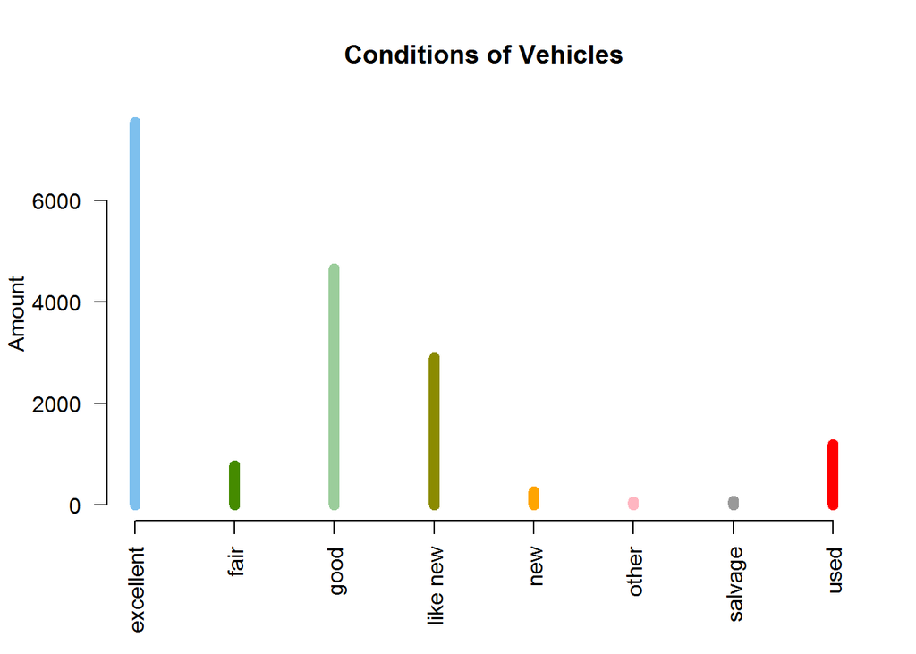

```r
plotNineColors = c("skyblue2",
                   "chartreuse4",
                   "darkseagreen3",
                   "yellow4",
                   "orange",
                   "lightpink",
                   "grey60",
                   "red")
plot(table(vposts$updatedCondition), las = 2,
     main = "Conditions of Vehicles", ylab = "Amount",
     lwd = 8, col = plotNineColors)
```

I combined all other categories into the top 8 categories (not in any particular order). I sorted the conditions based on the name (some were simply misspelled) and I checked a few and read the description. The graph looks much less crowded in the x-axis without any conditions that does not actually describe the description. This helps decreases confusion about the vehicle’s condition.

#### Anomaly 2

The second anoamly is human errors, such as price and year. The errors for price and year are causing the outliers.

```r
#get table of prices
table(vposts$price) #results hidden because too long
```

```r
which(vposts$price == "600030000")
```

```
## [1] 4741 4880
```

```r
#pontiac cars ranges between $20000 to $30000
vposts[4741,] #results hidden because too long

#pontiac also, same post as row 4741
vposts[4880,] #results hidden because too long
```

After reading the discription, the price was suppose to be between $6000 to $30000 depending on the car condition, so I changed the price to $6300.

```r
#change price of the two 600030000
vposts[4741, "price"] = 6300 #change the price from $600030000 to $6300
vposts[4880, "price"] = 6300 #change the price from $600030000 to $6300
```

```r
table(vposts$price) #results hidden because too long
```

If I were to fix the rest of the prices, most of the outliers of price would be eliminated. This results in the price distrubtion to be less skewed by extreme outliers.

```r
#get tables of year
table(vposts$year)
```

```r
#find which row the outliers are in
which(vposts$year == "4") #find which row
```

```
## [1] 8417
```

```r
#results hidden because too long
vposts[8417,] #get all the columns
```

```r
which(vposts$year == "2022") #find which row
```

```
## [1] 21975
```

```r
vposts[21975,] #get all the columns
```

```r
vposts[8417, "year"] = 2004 #change year from 4 to 2004
vposts[21975, "year"] = 2002 #change year from 2022 to 2002
```

Vehicle simply says 4 for year, I changed the year to 2004 because it is a Jeep Wrangler and those did not exist in 1904. The vehicle with year 2022 has an odometer reading of 117102, so it is an older vehicle. I changed the year to 2002. If we were to go through all the years of vehicles by reading the body/description, then the years of vehicles to be less skewed by extreme outliers. This is important because you want to be able know the vehicle’s real age when looking up vehicles by “year”.

#### Anomaly 3

```r
which(vposts$year == "1999" & vposts$maker == "ford" & vposts$odometer < 20000)
```

```
##  [1]  7644  7697  8945  9381 13966 14543 18664
##  [8] 23752 28368 29462 32921
```

```r
#results hidden because too long
vposts[7644,] #odometer is 121 but actually 121000
vposts[7697,] #odometer is 144
vposts[8945,] #odometer is 122 but actually 122000
vposts[9381,] #odometer is 169 but actually 169000
vposts[13966,] #odometer is 296
vposts[14543,] #odometer is 296
vposts[18664,] #odometer is 166
vposts[23752,] #odometer is 113 but actually 113000
vposts[28368,] #odometer is 118 but actually 118000
vposts[29462,] #odometer is 186 but actually 186000
vposts[23752,] #odometer is 113 but actually 140000
```

I noticed that after reading the body of all the rows for vehicles with year 1999, maker Ford, and with an odometer reading of 20000 or less, it contains vehicles that actually have a milage of 100000 or more! This means that there are likely other vehicles with incorrect odometer readings. The seller likely put an incorrect odometer reading that is much less than it actually is because buyers may narrow their search to “how price” and/or “low odometer reading” and their vehicle will show as top searches. It’s important to correct them because this is misleading about the condition of the vehicle. I can correct them by looking through all the posts, reading the body and decide if I need to fix the odometer reading.

### Part 2: Find at least 3 interesting insights/characteristics/features illustrated by the data. Explain in what way these insights are interesting (to whom? why?) and provide evidence for any inference/conclusions you draw. How generalizable are these insights to other vehicle sales data?

#### 1. Interesting insights/characteristics/features illustrated by the data

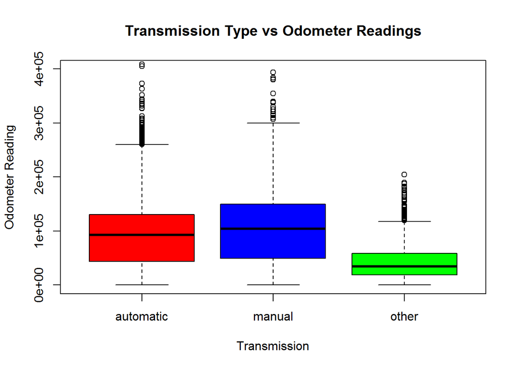

```r
odom_trans = split(vposts$odometer, vposts$transmission)
boxplot(odom_trans, main = "Transmission Type vs Odometer Readings",
        xlab = "Transmission", ylab = "Odometer Reading",
        ylim = c(0, 4e+05),
        col = c("red", "blue", "green"))
```

I compared relationship between odometer and the different types of transmission. “Automatic” and “manual” has a lot of and high odometer readings, while “other” has much less in and lower odometer readings in comparision. This means that vehicles under the transmission “other” are driven less or less popular. This is because other transmissions such as single-speed and dual-clutch are known for being fuel efficent or eco-friendly and these types of vehicle are not popular because they do not run as fast gas or diesel.

```r
#look for all the ones that are year 2015 while removing NAs
i = !is.na(vposts$year) & vposts$year == 2015
options(width = 70)
```

```r
vposts$body[i] #results hidden because too long
```

#### 3. Interesting insights/characteristics/features illustrated by the data

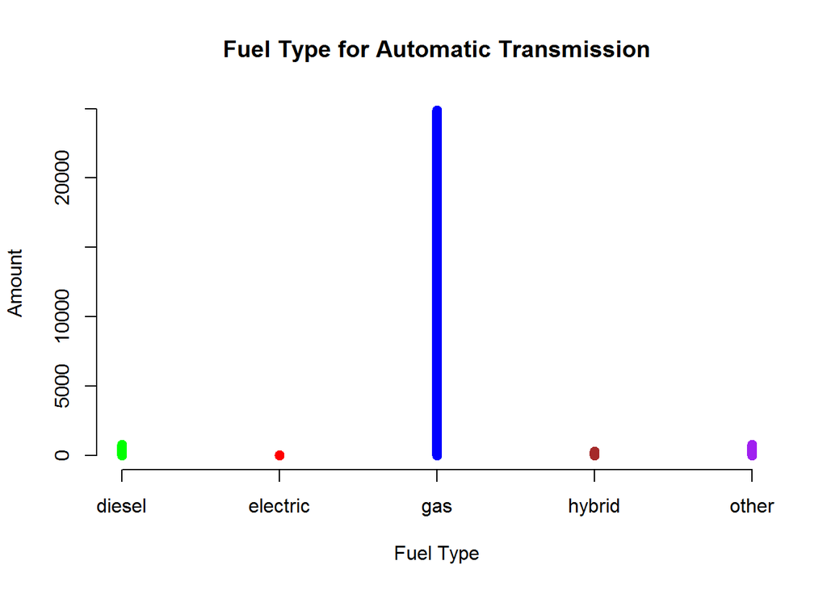

```r
bytrans = split(vposts, vposts$transmission)
by_trans_table = lapply(bytrans, function(d) table(d$fuel))

#Shows the relationship between vehicle type vs fuel type for automatic transmission
plot(by_trans_table$automatic,
     main = "Fuel Type for Automatic Transmission",
     xlab = "Fuel Type", ylab = "Amount", lwd = 8,
     col =  c("green", "red", "blue", "brown", "purple"))
```

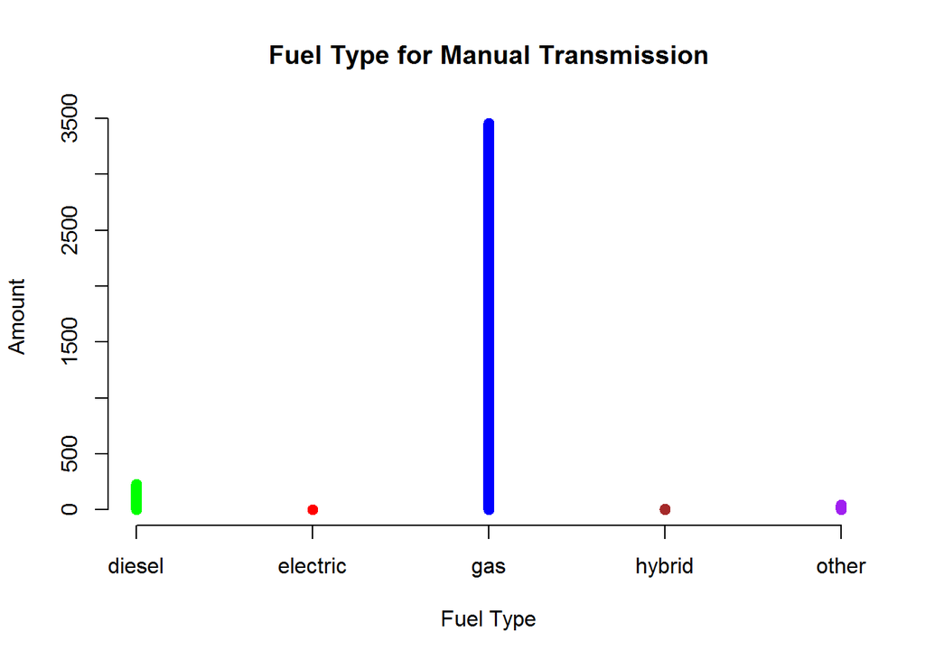

```r
#Shows the relationship between fuel type vs fuel for manual transmission
plot(by_trans_table$manual,
     main = "Fuel Type for Manual Transmission",
     xlab = "Fuel Type", ylab = "Amount", lwd = 8,
     col =  c("green", "red", "blue", "brown", "purple"))
```

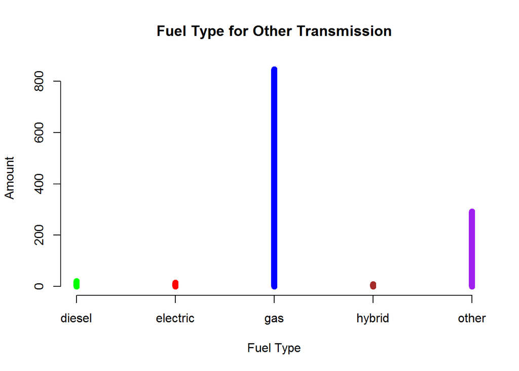

```r
#shows the relationship between type vs fuel for other transmission
plot(by_trans_table$other,
     main = "Fuel Type for Other Transmission",
     xlab = "Fuel Type", ylab = "Amount", lwd = 8,
     col =  c("green", "red", "blue", "brown", "purple"))
```

I noticed that both “automatic” and “manual” transmission have similar distribution of fuel type while “other” transmission has a large increase in “other” as the fuel type. Other types of transmission are single-speed and dual-clutch transmission. These two transmission are known to the fuel efficent/eco-friendly, so it likely uses “other” fuel such as ethanol or bio-diesel, which both are common alternatives to gas when being eco-friendly.

### Code Appendix

```r
print(load(url("http://eeyore.ucdavis.edu/stat141/Data/vehicles.rda")))
#example of how I checked conditions that did not match the top 8 conditions:

#vew all conditions
table(vposts$condition) #results hidden because too long
#look for which row
which(vposts$condition == "complete parts car, blown engine")
#read description and decide which
#category I want to place it into
vposts[3473,] #results hidden because too long
#combines pre-existing or create a new category into a new
#factor called any name of choice
cnd = as.character(vposts$condition)

used = c("pre owned",
         "preowned",
         "pre-owned",
         "preownes")

salvage = c("needs restoration!",
            "not running",
            "restoration project",
            "project car",
            "needs restored",
            "project",
            "rebuildable project",
            "needs work",
            "restore",
            "project",
            "needs bodywork",
            "needs work/for parts",
            "needs total restore")

fair = c("restoration",
         "restored",
         "nice rolling restoration")

like_new = c("very good",
           "like new")

other = c("0used",
          "carfax guarantee!!",
          "207,400",
          "certified",
          "ac/heater",
          "honnda",
          "parts",
          "nice teuck",
          "rough but runs",
          "front side damage",
          "hit and run :( gently",
          "mint",
          "nice",
          "complete parts car, blown engine",
          "muscle car restore",
          "superb original")

tmp_used = cnd %in% used #create temp variable
cnd[tmp_used] = "used" #name the category (can be a new category or pre-existing)
tmp_salvage = cnd %in% salvage
cnd[tmp_salvage] = "salvage"
tmp_fair = cnd %in% fair
cnd[tmp_fair] = "fair"
tmp_like_new = cnd %in% like_new
cnd[tmp_like_new] = "like new"
tmp_other = cnd %in% other
cnd[tmp_other] = "other"

options(width = 50) #easier to view

#turn back into a factor/level in conditions
vposts$updatedCondition = factor(cnd)
levels(vposts$updatedCondition) #view levels

plotNineColors = c("skyblue2",
                   "chartreuse4",
                   "darkseagreen3",
                   "yellow4",
                   "orange",
                   "lightpink",
                   "grey60",
                   "red")
plot(table(vposts$updatedCondition), las = 2,
     main = "Conditions of Vehicles", ylab = "Amount",
     lwd = 8, col = plotNineColors)
#get table of prices
table(vposts$price) #results hidden because too long
which(vposts$price == "600030000")
#pontiac cars ranges between $20000 to $30000
vposts[4741,] #results hidden because too long

#pontiac also, same post as row 4741
vposts[4880,] #results hidden because too long
#change price of the two 600030000
vposts[4741, "price"] = 6300 #change the price from $600030000 to $6300
vposts[4880, "price"] = 6300 #change the price from $600030000 to $6300
table(vposts$price) #results hidden because too long
#get tables of year
table(vposts$year)
#find which row the outliers are in
which(vposts$year == "4") #find which row
#results hidden because too long
vposts[8417,] #get all the columns
which(vposts$year == "2022") #find which row
vposts[21975,] #get all the columns
vposts[8417, "year"] = 2004 #change year from 4 to 2004
vposts[21975, "year"] = 2002 #change year from 2022 to 2002
which(vposts$year == "1999" & vposts$maker == "ford" & vposts$odometer < 20000)
#results hidden because too long
vposts[7644,] #odometer is 121 but actually 121000
vposts[7697,] #odometer is 144
vposts[8945,] #odometer is 122 but actually 122000
vposts[9381,] #odometer is 169 but actually 169000
vposts[13966,] #odometer is 296
vposts[14543,] #odometer is 296
vposts[18664,] #odometer is 166
vposts[23752,] #odometer is 113 but actually 113000
vposts[28368,] #odometer is 118 but actually 118000
vposts[29462,] #odometer is 186 but actually 186000
vposts[23752,] #odometer is 113 but actually 140000
odom_trans = split(vposts$odometer, vposts$transmission)
boxplot(odom_trans, main = "Transmission Type vs Odometer Readings",
        xlab = "Transmission", ylab = "Odometer Reading",
        ylim = c(0, 4e+05),
        col = c("red", "blue", "green"))
#look for all the ones that are year 2015 while removing NAs
i = !is.na(vposts$year) & vposts$year == 2015
options(width = 70)
vposts$body[i] #results hidden because too long
bytrans = split(vposts, vposts$transmission)
by_trans_table = lapply(bytrans, function(d) table(d$fuel))

#Shows the relationship between vehicle type vs fuel type for automatic transmission
plot(by_trans_table$automatic,
     main = "Fuel Type for Automatic Transmission",
     xlab = "Fuel Type", ylab = "Amount", lwd = 8,
     col =  c("green", "red", "blue", "brown", "purple"))

#Shows the relationship between fuel type vs fuel for manual transmission
plot(by_trans_table$manual,
     main = "Fuel Type for Manual Transmission",
     xlab = "Fuel Type", ylab = "Amount", lwd = 8,
     col =  c("green", "red", "blue", "brown", "purple"))

#shows the relationship between type vs fuel for other transmission
plot(by_trans_table$other,
     main = "Fuel Type for Other Transmission",
     xlab = "Fuel Type", ylab = "Amount", lwd = 8,
     col =  c("green", "red", "blue", "brown", "purple"))
```